# SkatSearch Walkthrough

# SkatSearch Analysis Progress

## Recent Achievements

### 1. Enhanced CSV Output

- **Context-Aware Sorting**: Cards are now sorted logically based on the best game type (e.g., Null games sort A-K-Q…, Suit games sort J-A-10…).
- **WonMask**: Added a `WonMask` column (e.g., `G--H-N`) indicating which game types are winnable (>66%) for a given hand.
- **BestGame Selection**: Refined logic to prefer **Grand** over Suit games and **Null** over simple Diamond games (based on game value) when win probabilities are equal.

### 2. Simulation & Server Migration

- **Bash Script**: Created `research/run_general_sim_50k.sh` for running large-scale simulations on Ubuntu servers.
- **Server Status**: Created `check_server_status.ps1` to monitor the remote simulation via SSH (checks process status and progress %).
- **Data Retrieval**: Created `fetch_server_results.ps1` to easily copy results to local machine.

### 4. Detailed Strength Analysis by Trump Count

Comprehensive analysis of hand strength, grouped by total length (Suit + Jacks). Sub-categories: 1. **Pre-Discard**: Biddability of the initial 10 cards. 2. **Post-Discard (Grand)**: Final strength for Grand Games. 3. **Post-Discard (Suit)**: Final strength for Suit Games (Clubs/Spades/etc.).

> [!TIP] **Viewing Interactive Charts**: The `[Interactive Chart (HTML)]` links below are HTML files. **Open them in an external browser** (Chrome, Edge) to see tooltips. VS Code blocks them. (Double-click the files in the `visualizations` folder I opened).

#### 4.1. The “4 Trumps” Zone (Extremely Weak)

Hands with only 4 potential trumps (e.g., 1 Jack + 3 Suit, or 0 Jacks + 4 Suit). * **Pre**: Almost unbiddable without 3 Fulls. * **Grand**: Very risky. * **Suit**: Requires massive side strength.

### **Summary PDF**

Download 2x2 Decision Map Summary (A4 Landscape PDF)

### 4 Trumps (Weak)

**Optimal Decision Map** *When to play Grand Hand (Blue), Suit Hand (Orange), or Pickup Skat (Green).* *Based on Expected Value: Grand Hand (2.66P-1.33), Suit Hand (2P-1), Pickup (3P-2).*

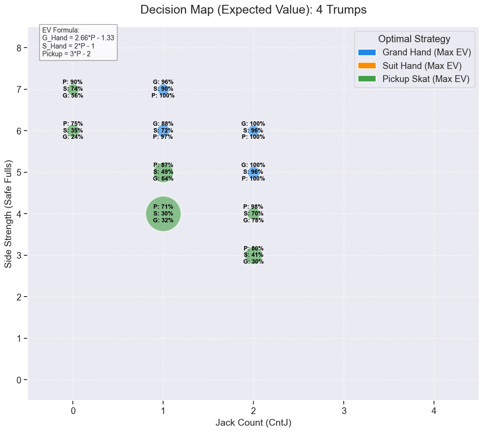

Interactive Chart (HTML)

**Pre-Discard (Biddability)**

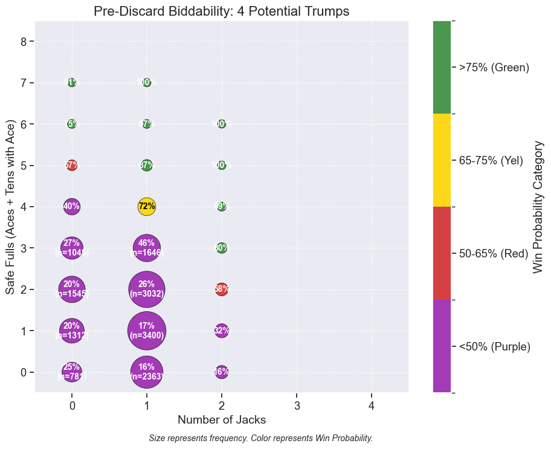

Interactive Chart (HTML)

**Suit Hand (Direct Play)**

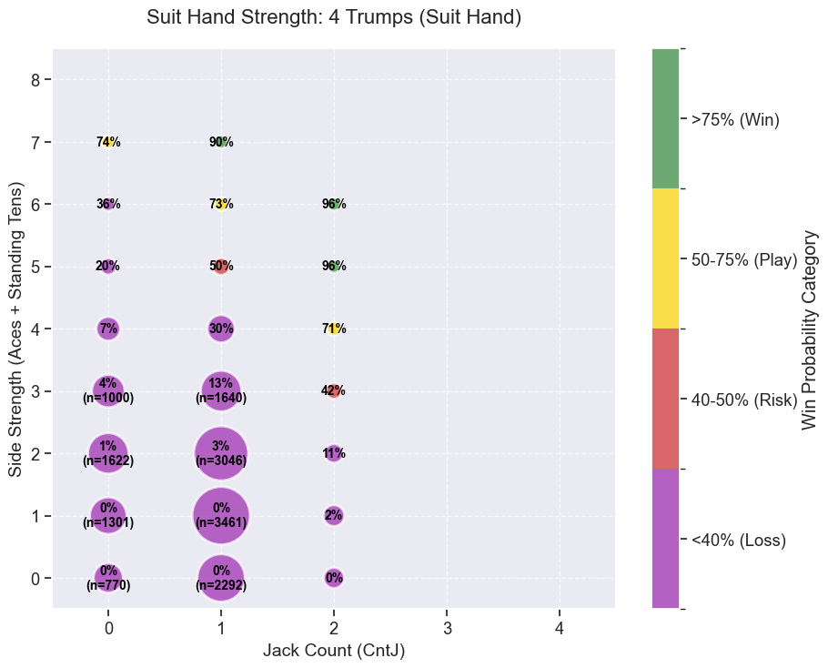

Interactive Chart (HTML)

**Grand Hand (Direct Play)**

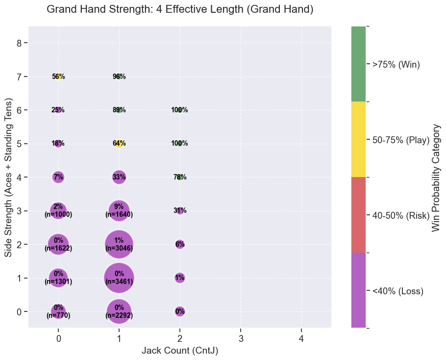

Interactive Chart (HTML)

**Post-Discard (Grand)**

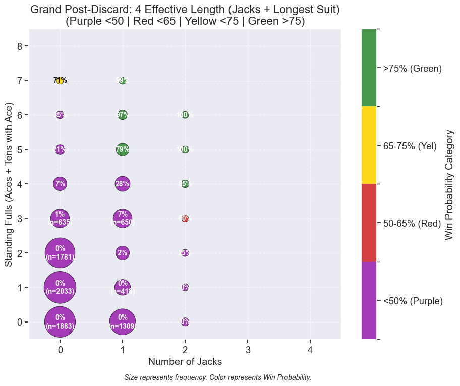

Interactive Chart (HTML)

**Post-Discard (Suit)**

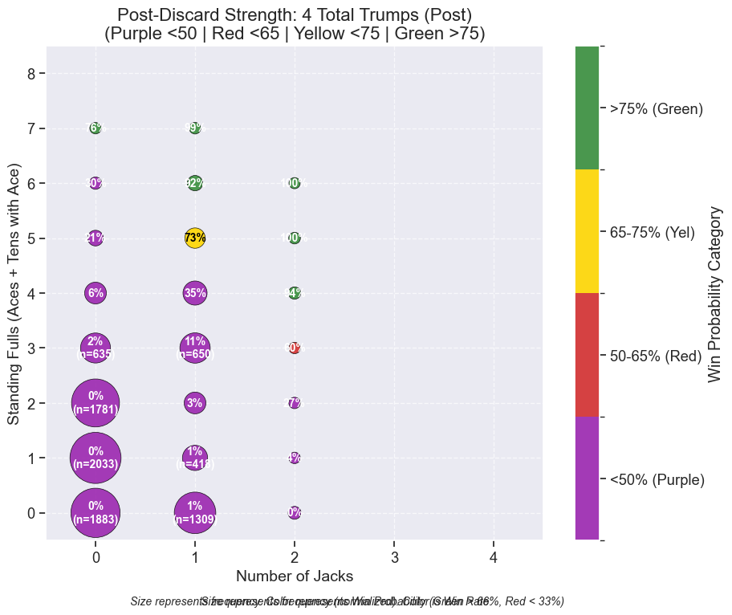

Interactive Chart (HTML)

#### 4.2. The “5 Trumps” Zone (The Danger Zone)

Hands with 5 potential trumps (e.g., 1 Jack + 4 Suit, or 2 Jacks + 3 Suit). * **Pre**: Often looks playable but is prone to “Stagnation Traps” (see Section 5). * **Hand**: Risky play without Skat knowledge. * **Grand**: Risky without 2 Fulls. * **Suit**: Still fragile.

### 5 Trumps (Weak/Medium)

**Optimal Decision Map** *When to play Grand Hand (Blue), Suit Hand (Orange), or Pickup Skat (Green).* *Based on Expected Value: Grand Hand (2.66P-1.33), Suit Hand (2P-1), Pickup (3P-2).*

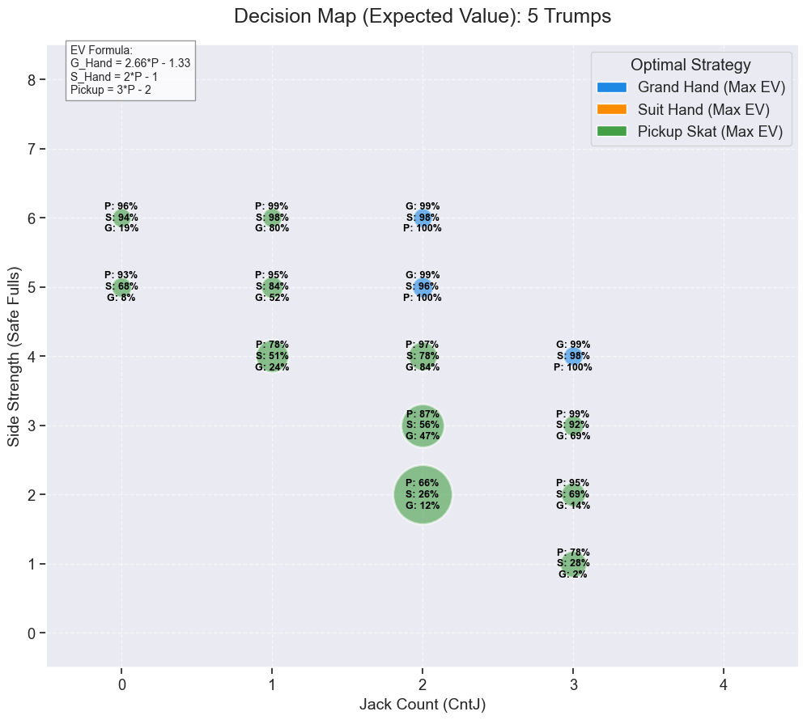

Interactive Chart (HTML)

**Pre-Discard (Biddability)**

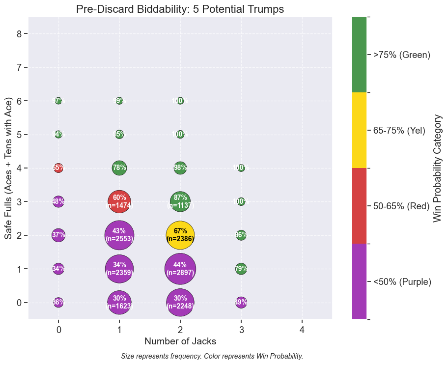

Interactive Chart (HTML)

**Suit Hand (Direct Play)**

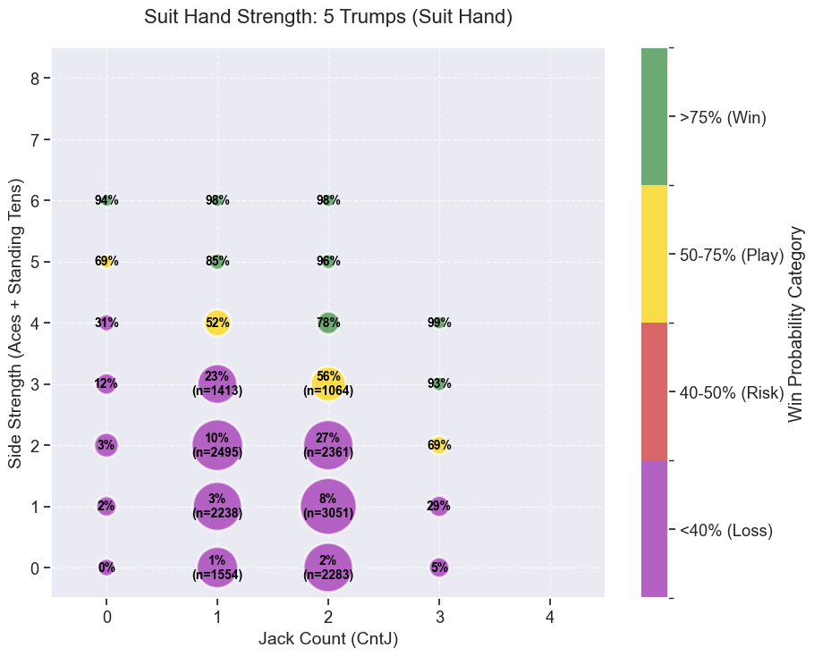

Interactive Chart (HTML)

**Grand Hand (Direct Play)**

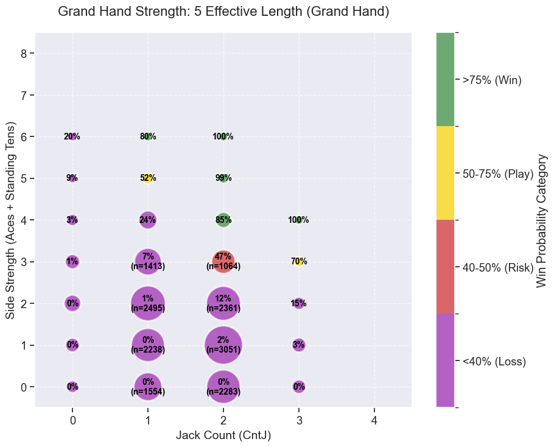

Interactive Chart (HTML)

**Post-Discard (Grand)**

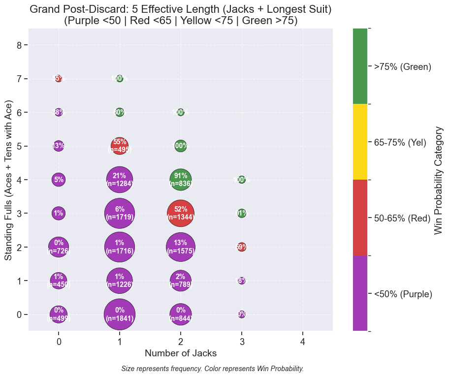

Interactive Chart (HTML)

**Post-Discard (Suit)**

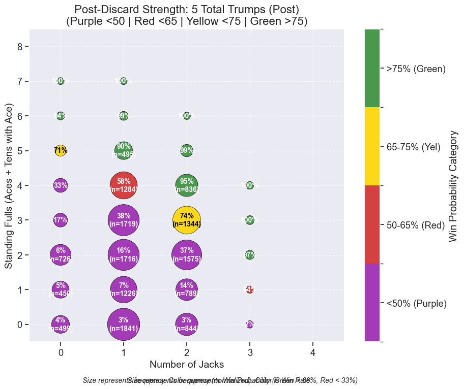

Interactive Chart (HTML)

#### 4.3. The “6 Trumps” Zone (Solid Play)

Hands with 6 potential trumps (e.g., 2 Jacks + 4 Suit). * **Pre**: Start of the safe bidding zone. * **Hand**: Good chance but check comparison. * **Grand**: Solid base. * **Suit**: Generally winning.

**Pre-Discard (Biddability)**

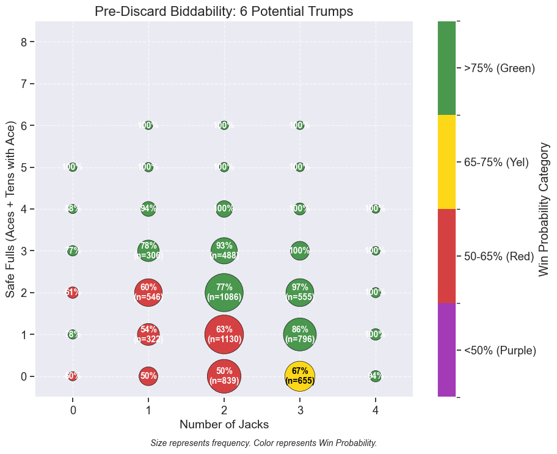

Interactive Chart (HTML)

**Suit Hand (Direct Play)**

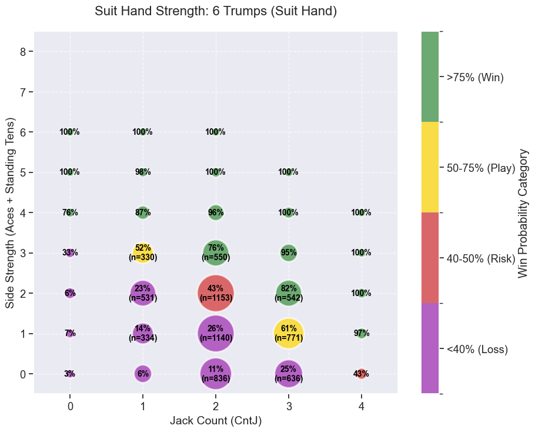

Interactive Chart (HTML)

**Grand Hand (Direct Play)**

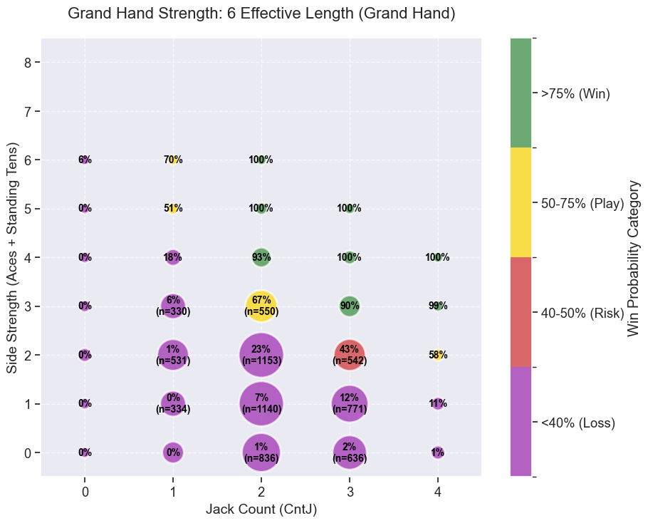

Interactive Chart (HTML)

**Post-Discard (Grand)**

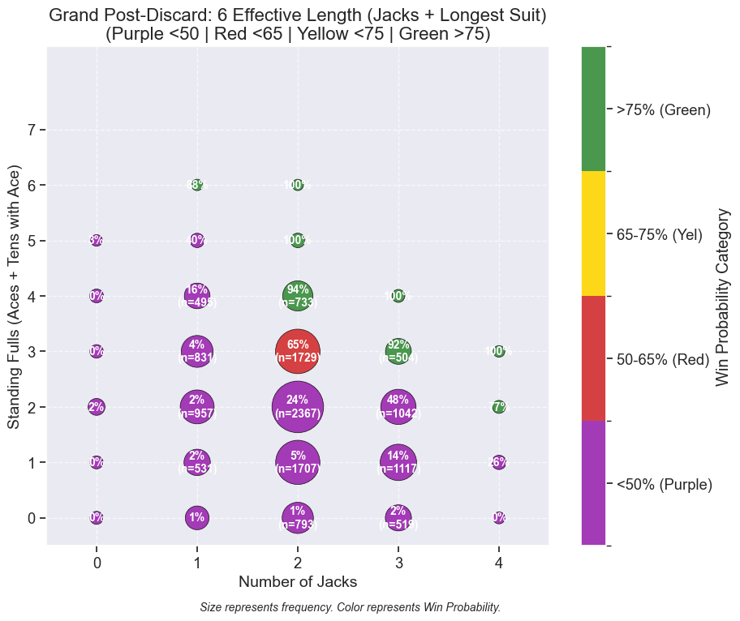

Interactive Chart (HTML)

**Post-Discard (Suit)**

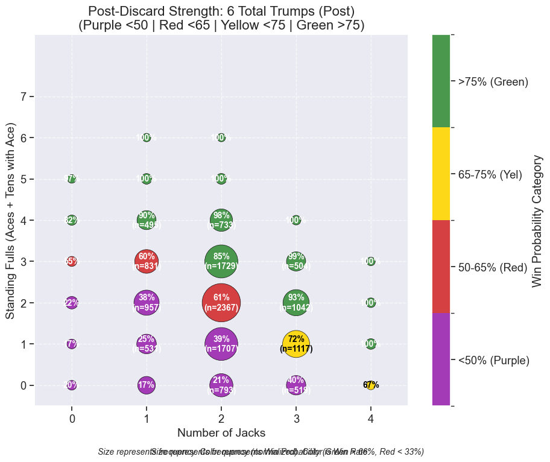

Interactive Chart (HTML)

#### 4.4. The “7+ Trumps” Zone (Dominant)

**Pre-Discard (Biddability)**

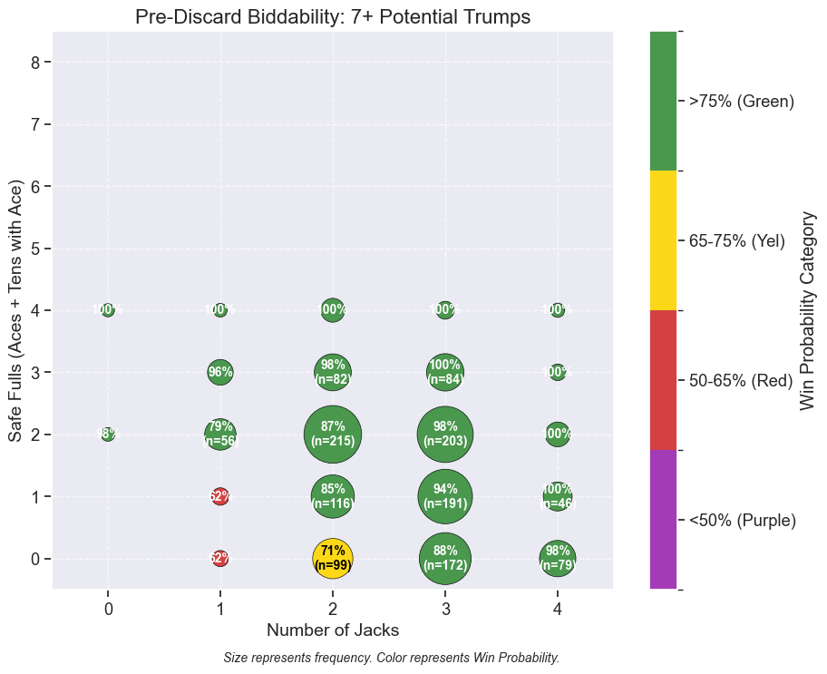

Interactive Chart (HTML)

**Suit Hand Strength**

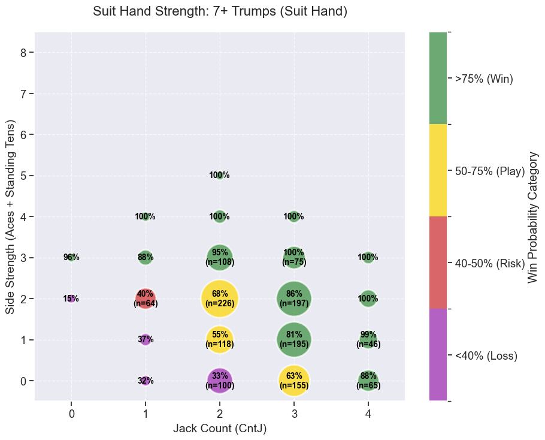

Interactive Chart (HTML)

**Grand Hand Strength**

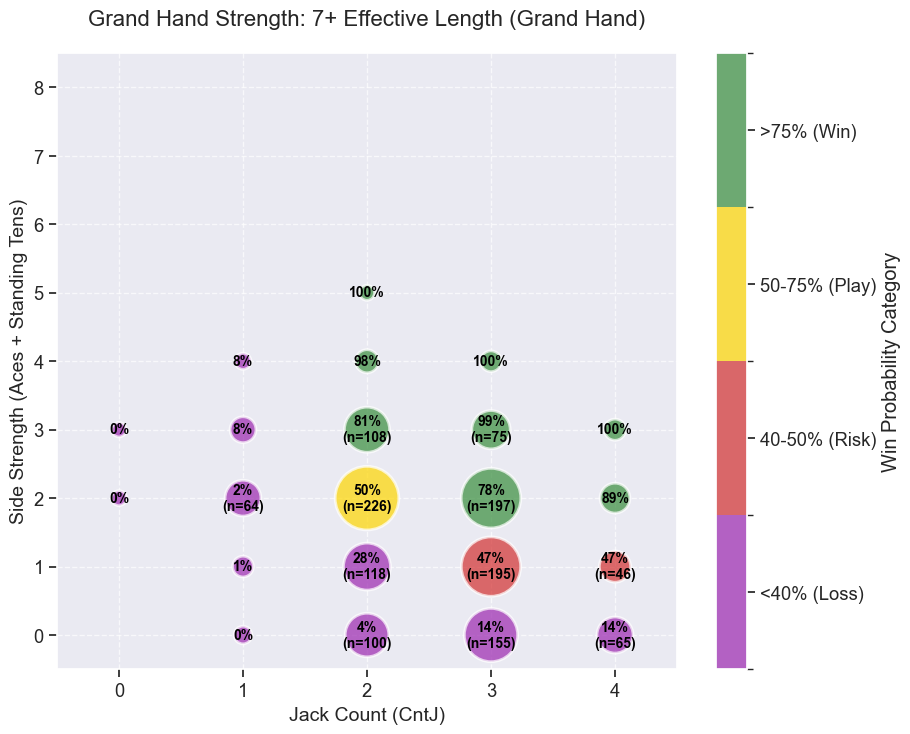

Interactive Chart (HTML)

**Post-Discard (Grand)**

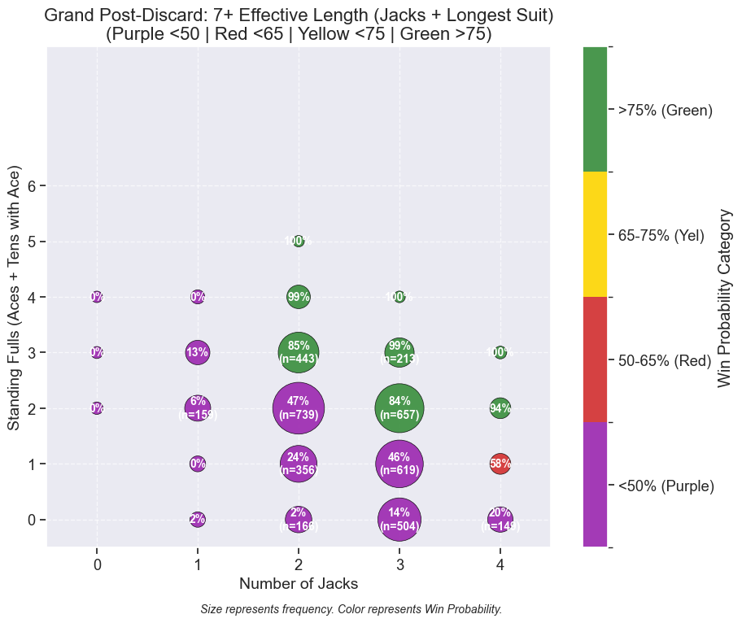

Interactive Chart (HTML)

**Post-Discard (Suit)**

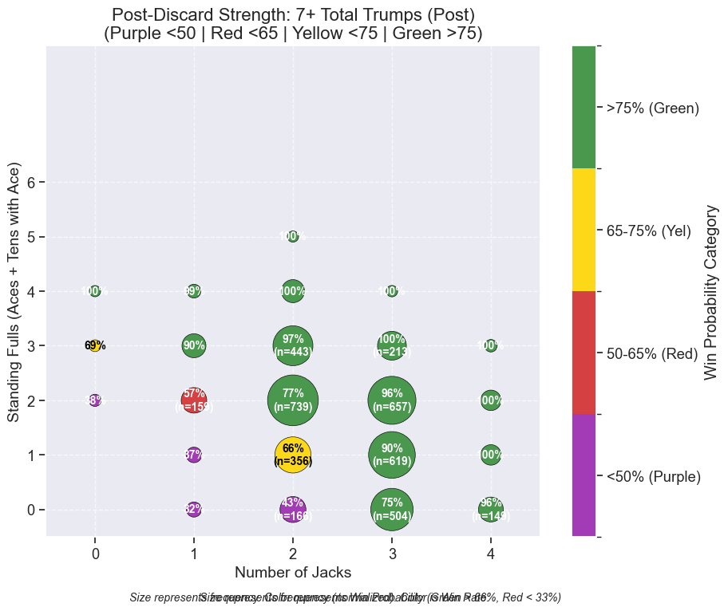

Interactive Chart (HTML)

### 6. Hand Game Strategy: The “Golden Rule”

**Question:** When should you play Hand instead of picking up the Skat? **Assumptions:** Hand Game is +33% value; Losing Skat Game is double penalty (-2x); Losing Hand Game is single penalty (-1.33x).

The expected value analysis reveals a “Decision Boundary”. You should play Hand if:

*P*<sub>*h**a**n**d*</sub> > 1.125 × *P*<sub>*s**k**a**t*</sub> − 0.25

**Key Decision Points:** * **If Skat Win is Guaranteed (100%)**: You need **>88%** Hand Win Probability to justify the risk of losing the extra points. * **If Skat Win is Strong (80%)**: You only need **>65%** Hand Win Probability. The lower penalty for losing a Hand game makes it attractive even with lower odds. * **If Skat Win is Shaky (60%)**: You only need **>43%** Hand Win Probability! It is statistically safer to play Hand and risk a small loss than to pick up and risk a double loss.

Interactive Decision Matrix

**Specific Recommendations (Where Hand > Pickup):** Comparing our data with this rule reveals specific “Blue Zones” where you should play Hand:

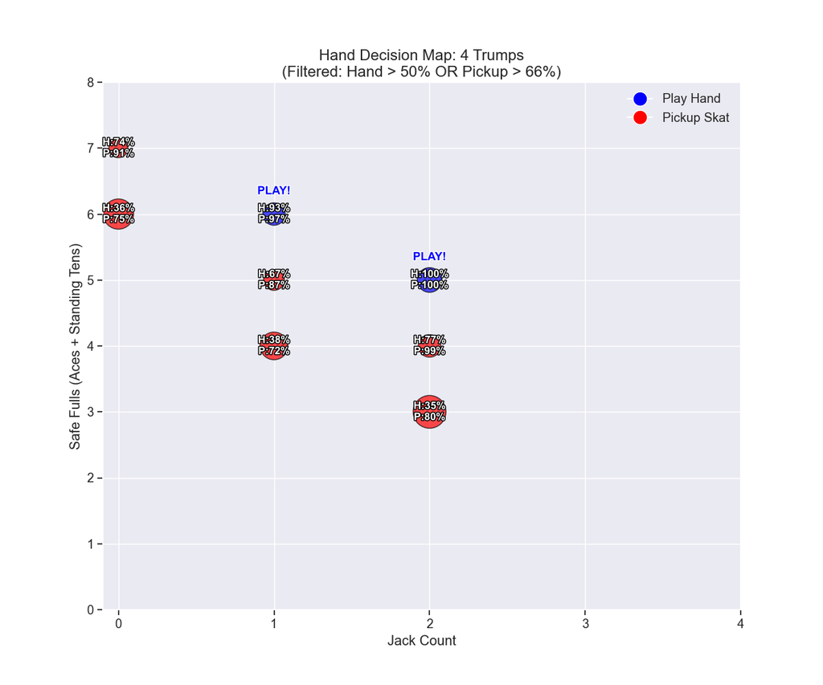

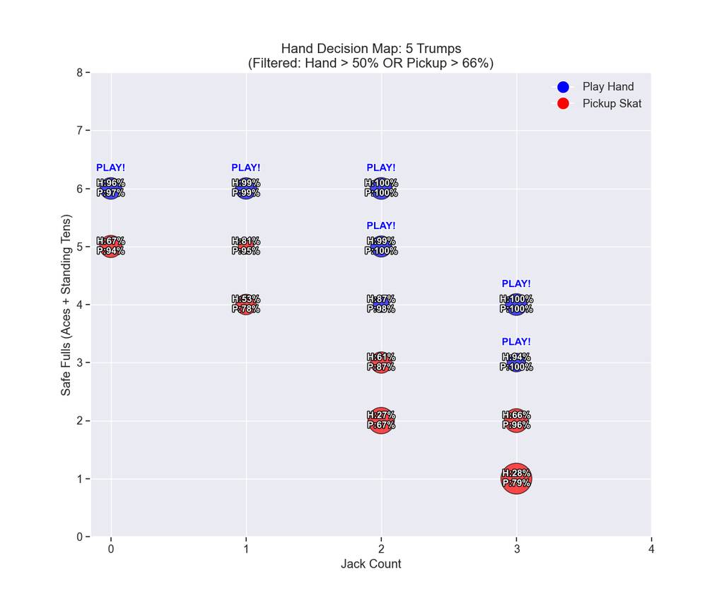

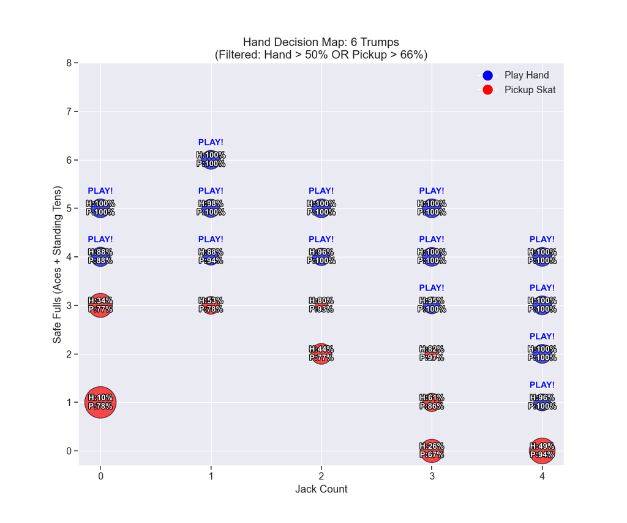

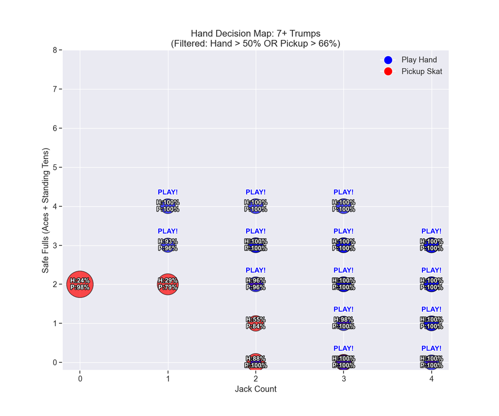

### 5. Skat Stagnation Traps (“The Disappointment Gap”)

What happens when you rely on the Skat, but the Skat doesn’t improve your hand (“Stagnation”)? Comparing “Expected Win Rate” (Pre-Discard) vs “Realized Win Rate” (Post-Discard for stagnant hands).

**Trappy Signatures** (Look winning initially (>66%), but if Skat is bad, they become losing (<66%)):

| Signature (Total Trumps / Jacks / Fulls) | Pre-Prob | Post-Prob (Stagnant) | Loss |
| --- | --- | --- | --- |
| **5 Trumps / 0 Jacks / 4 Fulls** | 69% | **38%** | -31% |
| **5 Trumps / 2 Jacks / 2 Fulls** | 69% | **39%** | -30% |
| **6 Trumps / 2 Jacks / 1 Full** | 69% | **42%** | -27% |
| **5 Trumps / 3 Jacks / 1 Full** | 76% | **53%** | -24% |

**Key Insight**: Hands with **5 Total Trumps** (e.g. 1J+4S or 2J+3S) are often “Pre-Winners” because they *hope* for a 6th Trump. If they don’t get it, they crash.

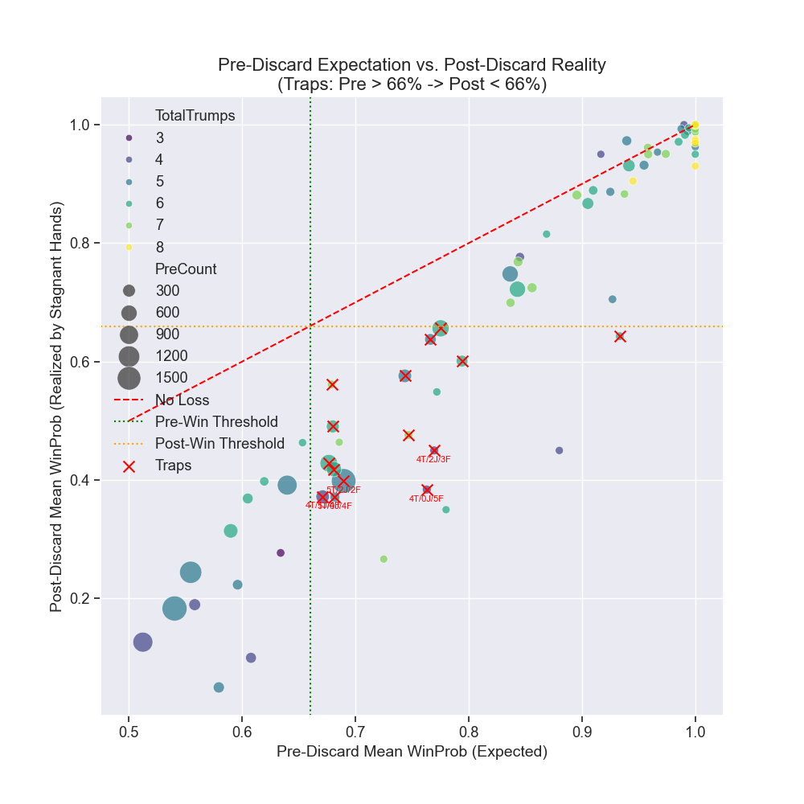

Interactive Chart (HTML)

## Next Steps

- Run the full 50k simulation on the server.
- Analyze results (using the improved CSV structure) to refine bidding rules further.